# What makes wine taste good or bad?

Kyle Shannon

June 23, 2016

## Abstract

Exploratory Data Analysis (EDA) on a complete data set with 12 variables and 1599 observations. This data set is about Red Wine and includes both chemically measured (11 variables) properties of the wine and 1 sensory measured quality of the wine. The sensory measurement was a rating given by wine experts on a 10 point scale (1 = worst, 10 = best) about the quality of the wine. The goal of this exploratory analysis is to get a better understanding of the underlying data, the chmical properties that make up the wine and how they may impact the quality.

A guiding question would be: Are their any trends in the data to suggest that certain chemical properties influence a wine’s quality rating?

## Introduction

To begin I will start by plotting univariate data plots. i want to get a feel for each feature in the data set and look at the variance of the data. Are there any outlandish outliers? Are there trends in each variable, i.e. 25% of one variable is a 0.00 or some other discrete value. Also what are the distributions of data? Is there many skewed distributions? Or perhaps bimodal distributions. Capturing this along with a summary (quartiles, median, mean, mode) of each feature is my starting point.

I will then go into creating new features and bivariate analysis looking at correlation between the features. I am especially curious if any features correlate with quality. If there is a correlation then what might be the cause?

Finally Iwill take all I have learned and being to look at multivariate data.

## Basic Overall Exploration

```
##  fixed.acidity   volatile.acidity  citric.acid    residual.sugar
##  Min.   : 4.60   Min.   :0.1200   Min.   :0.000   Min.   : 0.900
##  1st Qu.: 7.10   1st Qu.:0.3900   1st Qu.:0.090   1st Qu.: 1.900
##  Median : 7.90   Median :0.5200   Median :0.260   Median : 2.200
##  Mean   : 8.32   Mean   :0.5278   Mean   :0.271   Mean   : 2.539
##  3rd Qu.: 9.20   3rd Qu.:0.6400   3rd Qu.:0.420   3rd Qu.: 2.600
##  Max.   :15.90   Max.   :1.5800   Max.   :1.000   Max.   :15.500
##    chlorides       free.sulfur.dioxide total.sulfur.dioxide
##  Min.   :0.01200   Min.   : 1.00       Min.   :  6.00
##  1st Qu.:0.07000   1st Qu.: 7.00       1st Qu.: 22.00
##  Median :0.07900   Median :14.00       Median : 38.00
##  Mean   :0.08747   Mean   :15.87       Mean   : 46.47
##  3rd Qu.:0.09000   3rd Qu.:21.00       3rd Qu.: 62.00
##  Max.   :0.61100   Max.   :72.00       Max.   :289.00
##     density             pH          sulphates         alcohol
##  Min.   :0.9901   Min.   :2.740   Min.   :0.3300   Min.   : 8.40
##  1st Qu.:0.9956   1st Qu.:3.210   1st Qu.:0.5500   1st Qu.: 9.50
##  Median :0.9968   Median :3.310   Median :0.6200   Median :10.20
##  Mean   :0.9967   Mean   :3.311   Mean   :0.6581   Mean   :10.42
##  3rd Qu.:0.9978   3rd Qu.:3.400   3rd Qu.:0.7300   3rd Qu.:11.10
##  Max.   :1.0037   Max.   :4.010   Max.   :2.0000   Max.   :14.90
##     quality
##  Min.   :3.000
##  1st Qu.:5.000
##  Median :6.000
##  Mean   :5.636
##  3rd Qu.:6.000
##  Max.   :8.000
```

```
## 'data.frame':    1599 obs. of  12 variables:
##  $ fixed.acidity       : num  7.4 7.8 7.8 11.2 7.4 7.4 7.9 7.3 7.8 7.5 ...
##  $ volatile.acidity    : num  0.7 0.88 0.76 0.28 0.7 0.66 0.6 0.65 0.58 0.5 ...
##  $ citric.acid         : num  0 0 0.04 0.56 0 0 0.06 0 0.02 0.36 ...
##  $ residual.sugar      : num  1.9 2.6 2.3 1.9 1.9 1.8 1.6 1.2 2 6.1 ...
##  $ chlorides           : num  0.076 0.098 0.092 0.075 0.076 0.075 0.069 0.065 0.073 0.071 ...
##  $ free.sulfur.dioxide : num  11 25 15 17 11 13 15 15 9 17 ...
##  $ total.sulfur.dioxide: num  34 67 54 60 34 40 59 21 18 102 ...
##  $ density             : num  0.998 0.997 0.997 0.998 0.998 ...
##  $ pH                  : num  3.51 3.2 3.26 3.16 3.51 3.51 3.3 3.39 3.36 3.35 ...
##  $ sulphates           : num  0.56 0.68 0.65 0.58 0.56 0.56 0.46 0.47 0.57 0.8 ...
##  $ alcohol             : num  9.4 9.8 9.8 9.8 9.4 9.4 9.4 10 9.5 10.5 ...
##  $ quality             : int  5 5 5 6 5 5 5 7 7 5 ...
```

The above summary(data) and str(data) provides an overall view of the data types, Min/ Max, Mean/ Median and the quartiles. I get a sense that a lot of the data is skewed, i.e. “total.sulfur.dioxide” Let’s start with some simple histogram plots of each variable, along with a summary of the variable.

## Variable Distributions - Univariate Analysis

### Fixed Acidity Hist/ Summary:

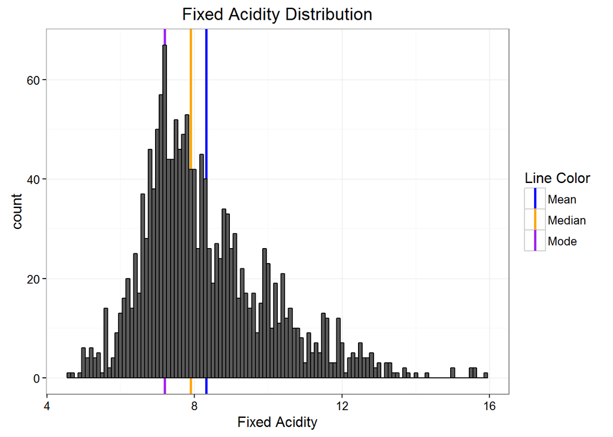

```
##    Min. 1st Qu.  Median    Mean 3rd Qu.    Max.
##    4.60    7.10    7.90    8.32    9.20   15.90
```

```
## [1] "Mode:  7.2"
```

Fixed Acidity (tartaric acids) has a right skew favoring slightly higher acidity.

### Volatile Acidity Hist/ Summary:

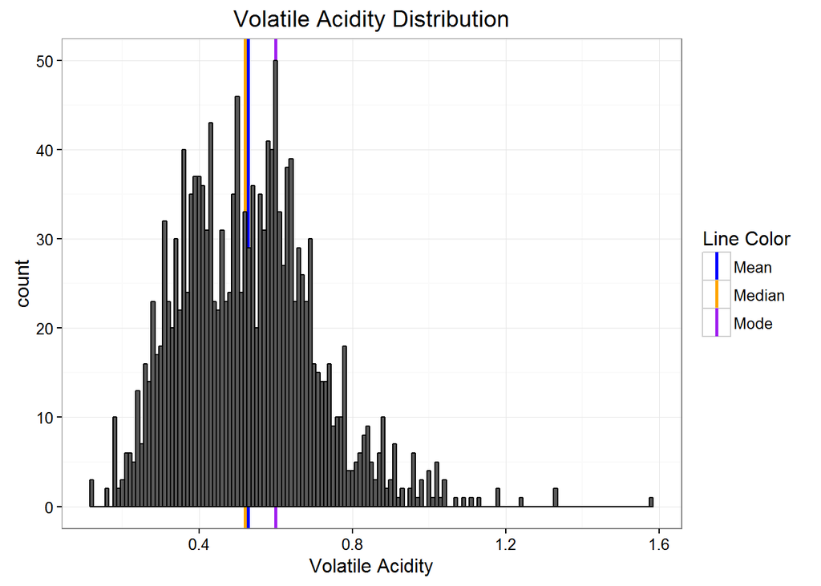

```
##    Min. 1st Qu.  Median    Mean 3rd Qu.    Max.
##  0.1200  0.3900  0.5200  0.5278  0.6400  1.5800
```

```
## [1] "Mode:  0.6"
```

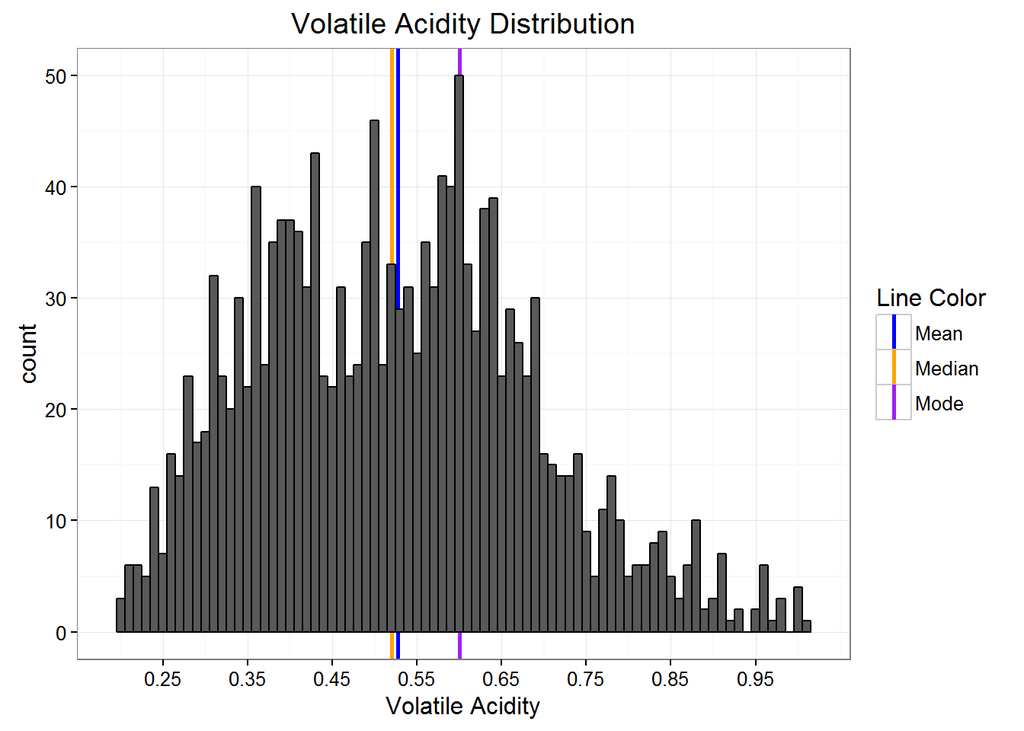

Volatile Acidity (acetic acid in the wine) appears to have a slight bimodal distribution with a right-handed skew. A quick look at the data table shows that the highest volatile acidic rating (1.58) has the lowest quality rating in the data set (3). The lowest volatile rating (.120) has the 2nd highest score for quality (7). A cursory glance at the lowest and highest volatile numbers follow suite with higher and lower quality ratings. This will certainly be an interesting feature that might be able to help predict red wine quality and will require further exploration.

### Citric Acid Hist/ Summary:

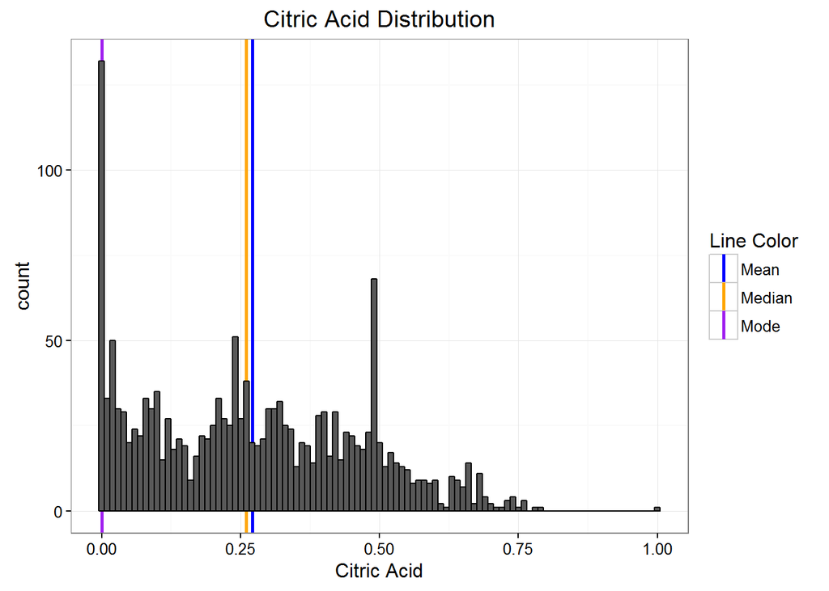

```
##    Min. 1st Qu.  Median    Mean 3rd Qu.    Max.
##   0.000   0.090   0.260   0.271   0.420   1.000
```

```
## [1] "Mode:  0"
```

Citric Acid can add freshness and flavor to the wine. A quick look at the raw data showed that both wines that were rated as good (~6) had both 0 citric acid present and a hightened amount (~0.75). Perhaps presence of citric acid can not harm the wine, but can potentially improve its freshness? However the potential outlier of 1.00 citric acid did hav a lower quality rating (4). This will be interesting to explore further. Another interesting observation is that so many wines have a citric acid value of 0.49. This seems odd for so many wines to have this exact value. The fact that there are so many 0.00 citric acid reading could be more plausible if those wines were made with some different ingrediants or with a different process.

### Residual Sugar Hist/ Summary:

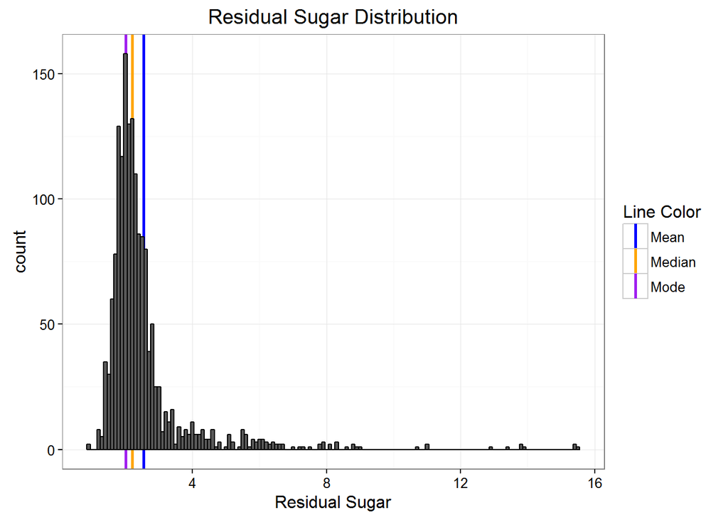

```
##    Min. 1st Qu.  Median    Mean 3rd Qu.    Max.
##   0.900   1.900   2.200   2.539   2.600  15.500
```

```
## [1] "Mode:  2"
```

Residual Sugar is the remaining sugar after fermentation stops. Wines with more than 45 g / dm^3 are considered sweet. We have no “sweet” wines in our data. Wines with less than 1.00 g / dm^3 are consiered rare. We have only two of those wines, both at 0.9. Therefore our wine list is not skewed by wines with rare residual sugar readings or sweet wines. Most of the wines in this data set are under 4 g / dm^3. It looks fairly normally distributed, except for the right handed skewness.

### Chlorides Hist/ Summary:

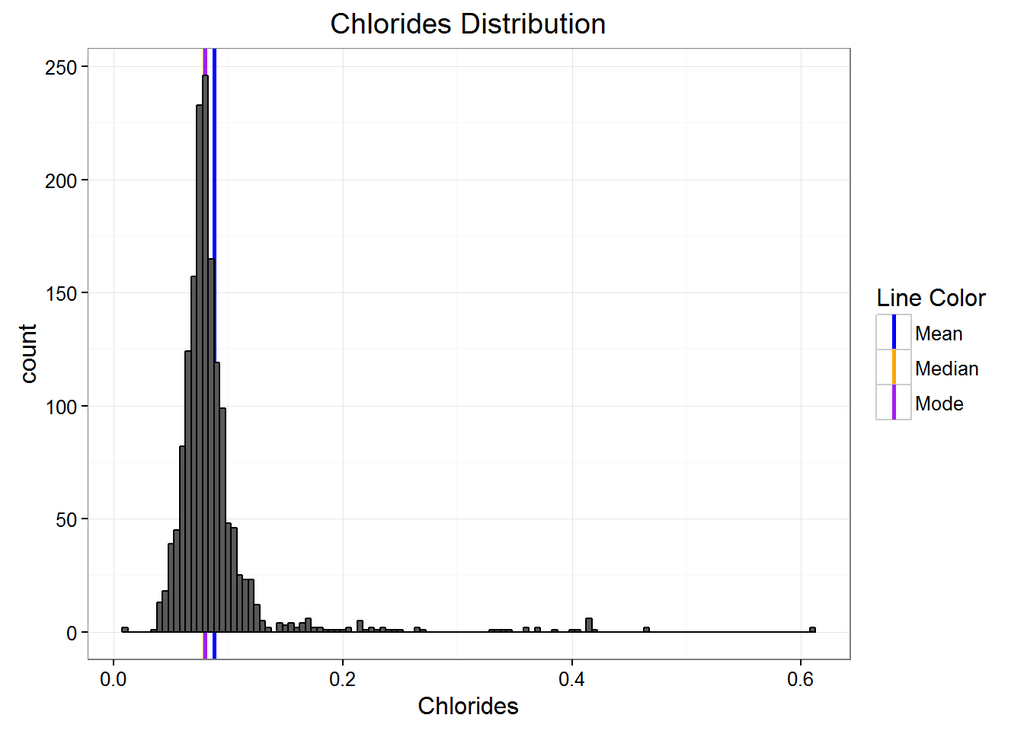

```
##    Min. 1st Qu.  Median    Mean 3rd Qu.    Max.
## 0.01200 0.07000 0.07900 0.08747 0.09000 0.61100
```

```
## [1] "Mode:  0.08"
```

Chlorides data is the amount of salt in the wine. Looks normally distrtibuted, except for some right handed skewness. Smome potential outliers may be present as well. It looks like there may be a slight negative correlation between the amount of chlorides and quality. This will be looked into when we start looking at variable interactions.

### Free Sulfur Dioxide Hist/ Summary:

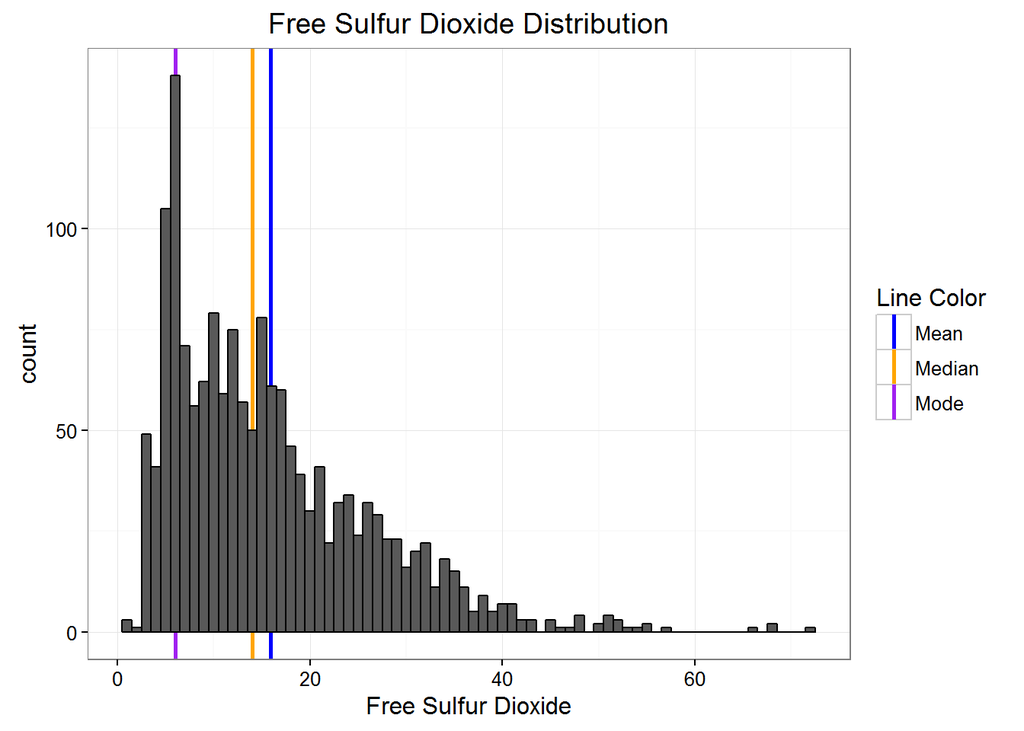

```
##    Min. 1st Qu.  Median    Mean 3rd Qu.    Max.
##    1.00    7.00   14.00   15.87   21.00   72.00
```

```
## [1] "Mode:  6"
```

Free Sulfar Dioxide prevents microbial growth and the oxidation of wine. I would suspect that there may be an optimal range for sulfur dioxide as a preservative, but too much may taint the taste and too little may not provide the wine enough protection. The distribution of dioxides is heavily righthanded skewed. From a cursory glance there does not seem to be a difference in the quality between low, medium and high number of dioxides.

### Total Sulfur Dioxide Hist/ Summary:

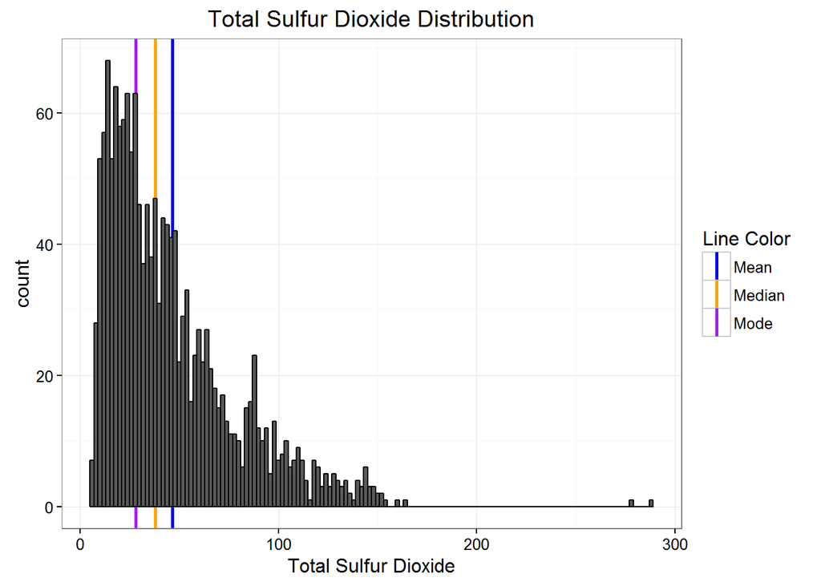

```
##    Min. 1st Qu.  Median    Mean 3rd Qu.    Max.
##    6.00   22.00   38.00   46.47   62.00  289.00
```

```
## [1] "Mode:  28"
```

Total sulfur dioxide below 50 ppm is mostly undetectable. This data is highly skewed right.

### Density Hist/ Summary:

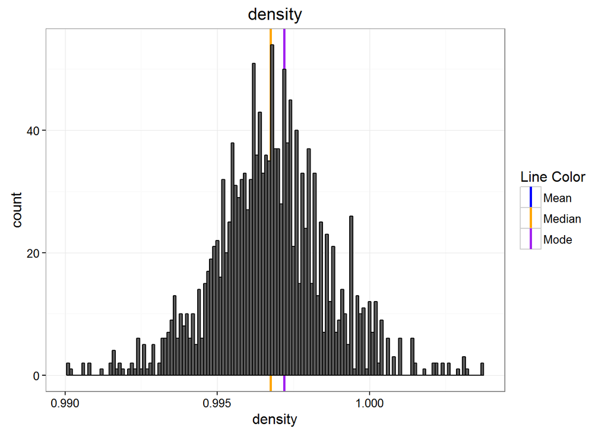

```
##    Min. 1st Qu.  Median    Mean 3rd Qu.    Max.
##  0.9901  0.9956  0.9968  0.9967  0.9978  1.0040
```

```
## [1] "Mode:  0.9972"
```

Density is close to H2O depending in the amount of sugar and alcohol present. This data looks fairly normally distributed.

### pH Hist/ Summary:

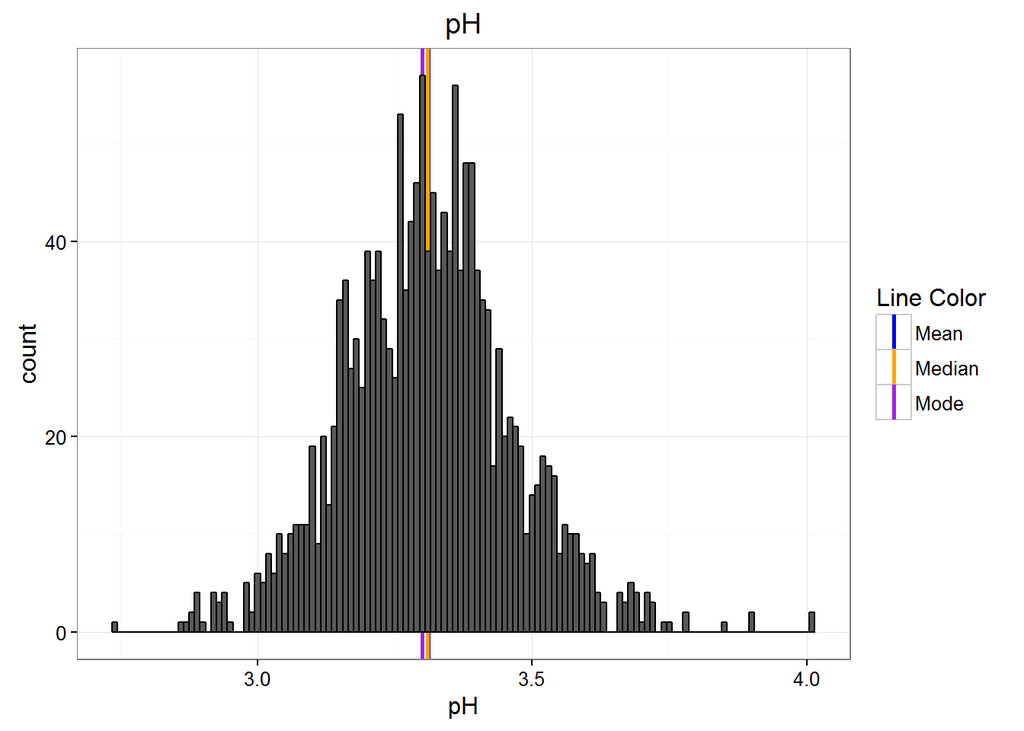

```
##    Min. 1st Qu.  Median    Mean 3rd Qu.    Max.
##   2.740   3.210   3.310   3.311   3.400   4.010
```

```
## [1] "Mode:  3.3"
```

pH describes the acidity of the wine. This data seems normally distributed.

### Sulphates Hist/ Summary:

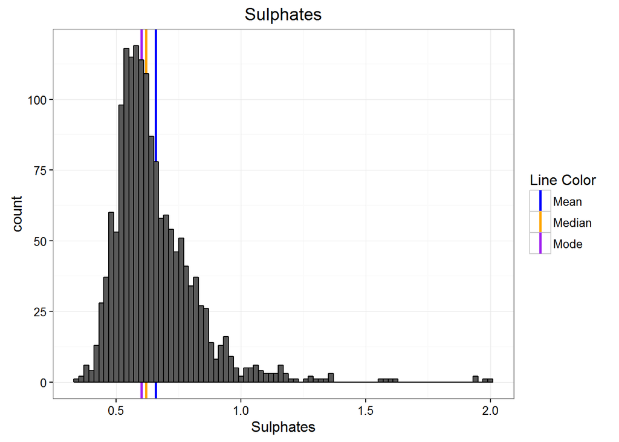

```
##    Min. 1st Qu.  Median    Mean 3rd Qu.    Max.
##  0.3300  0.5500  0.6200  0.6581  0.7300  2.0000
```

```
## [1] "Mode:  0.6"
```

Sulphates contribute to SO2. These are probably correlated. Suplhates data is slightly right handed skewed. Some outliers perhaps.

### Alcohol Hist/ Summary:

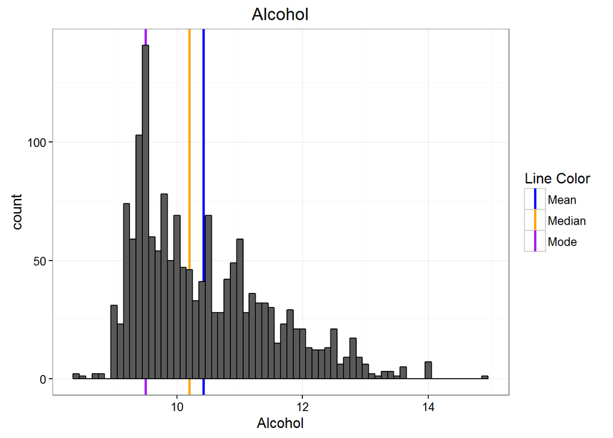

```
##    Min. 1st Qu.  Median    Mean 3rd Qu.    Max.
##    8.40    9.50   10.20   10.42   11.10   14.90
```

```
## [1] "Mode:  9.5"
```

Alcohol data represents the % of alchohol in wine. Heavy right handed skewness. Cursory view seems to suggest that alcohol has a positive correlation with quality.

### Quality Hist/ Summary:

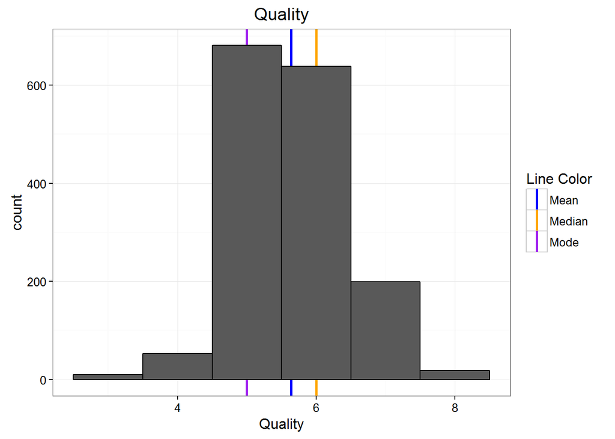

```
##    Min. 1st Qu.  Median    Mean 3rd Qu.    Max.
##   3.000   5.000   6.000   5.636   6.000   8.000
```

```
## [1] "Mode:  5"
```

Quality is on a 10 point scale (1=worst, 10=best) In this data set the values fall between 3 - 8. Most scores were 5 and 6. Most wines were subjectively ok. Very few wines were rated either 3 or 8.

## Univariate Analysis

I do not think chlorides will be a very important feature from what I have observed and reading the project’s data dictionary. Acidity, residual sugar, sulphates and sulfar dioxide are features that have interesting distributions.

## Feature Engineering

I wanted to see how pH and acids correlate to each other and if quality can be partly explained by these interactions. I know that pH id dependant on acids and bases. I also know citric acid can be thought of as good, while volatile acid can be thought of as bad. But lrt’s create a new feature called total.acids. I believe this should be a combination of all three acid features.

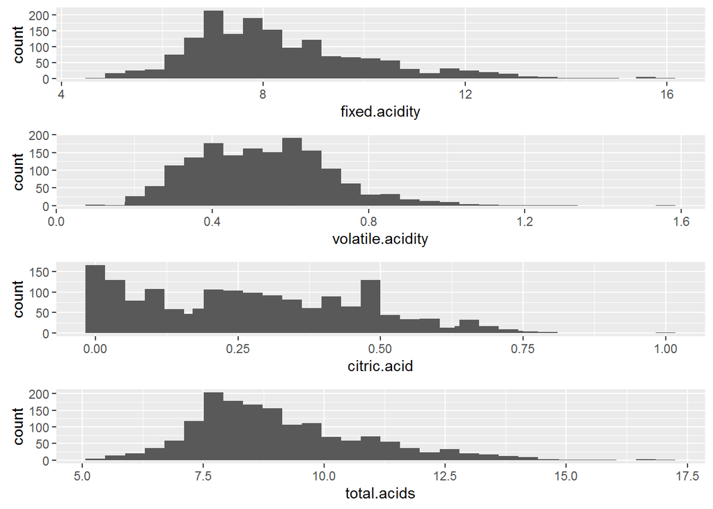

This might not be too helpful. As citric and volatile acids make up such a small % of fixed acidity. You can see how the distribution of volatile and citric acid are completely different from total and fixed. Ttoal and fixed look almost identical.

## Bivariate Plots

### Correlation Heatmap Matrtix for all features

```
##                     fixed.acidity volatile.acidity citric.acid
## fixed.acidity                1.00            -0.26        0.67
## volatile.acidity            -0.26             1.00       -0.55
## citric.acid                  0.67            -0.55        1.00
## residual.sugar               0.11             0.00        0.14
## chlorides                    0.09             0.06        0.20
## free.sulfur.dioxide         -0.15            -0.01       -0.06
##                     residual.sugar chlorides free.sulfur.dioxide
## fixed.acidity                 0.11      0.09               -0.15
## volatile.acidity              0.00      0.06               -0.01
## citric.acid                   0.14      0.20               -0.06
## residual.sugar                1.00      0.06                0.19
## chlorides                     0.06      1.00                0.01
## free.sulfur.dioxide           0.19      0.01                1.00
##                     total.sulfur.dioxide density    pH sulphates alcohol
## fixed.acidity                      -0.11    0.67 -0.68      0.18   -0.06
## volatile.acidity                    0.08    0.02  0.23     -0.26   -0.20
## citric.acid                         0.04    0.36 -0.54      0.31    0.11
## residual.sugar                      0.20    0.36 -0.09      0.01    0.04
## chlorides                           0.05    0.20 -0.27      0.37   -0.22
## free.sulfur.dioxide                 0.67   -0.02  0.07      0.05   -0.07
##                     quality total.acids
## fixed.acidity          0.12        1.00
## volatile.acidity      -0.39       -0.20
## citric.acid            0.23        0.69
## residual.sugar         0.01        0.12
## chlorides             -0.13        0.12
## free.sulfur.dioxide   -0.05       -0.15
```

```
##             fixed.acidity volatile.acidity citric.acid residual.sugar
## density              0.67             0.02        0.36           0.36
## pH                  -0.68             0.23       -0.54          -0.09
## sulphates            0.18            -0.26        0.31           0.01
## alcohol             -0.06            -0.20        0.11           0.04
## quality              0.12            -0.39        0.23           0.01
## total.acids          1.00            -0.20        0.69           0.12
##             chlorides free.sulfur.dioxide total.sulfur.dioxide density
## density          0.20               -0.02                 0.07    1.00
## pH              -0.27                0.07                -0.07   -0.34
## sulphates        0.37                0.05                 0.04    0.15
## alcohol         -0.22               -0.07                -0.21   -0.50
## quality         -0.13               -0.05                -0.19   -0.17
## total.acids      0.12               -0.15                -0.10    0.68
##                pH sulphates alcohol quality total.acids
## density     -0.34      0.15   -0.50   -0.17        0.68
## pH           1.00     -0.20    0.21   -0.06       -0.68
## sulphates   -0.20      1.00    0.09    0.25        0.18
## alcohol      0.21      0.09    1.00    0.48       -0.07
## quality     -0.06      0.25    0.48    1.00        0.10
## total.acids -0.68      0.18   -0.07    0.10        1.00
```

```
##                  Var1          Var2 value
## 1       fixed.acidity fixed.acidity  1.00
## 2    volatile.acidity fixed.acidity -0.26
## 3         citric.acid fixed.acidity  0.67
## 4      residual.sugar fixed.acidity  0.11
## 5           chlorides fixed.acidity  0.09
## 6 free.sulfur.dioxide fixed.acidity -0.15
```

```
##            Var1        Var2 value
## 164     density total.acids  0.68
## 165          pH total.acids -0.68
## 166   sulphates total.acids  0.18
## 167     alcohol total.acids -0.07
## 168     quality total.acids  0.10
## 169 total.acids total.acids  1.00
```

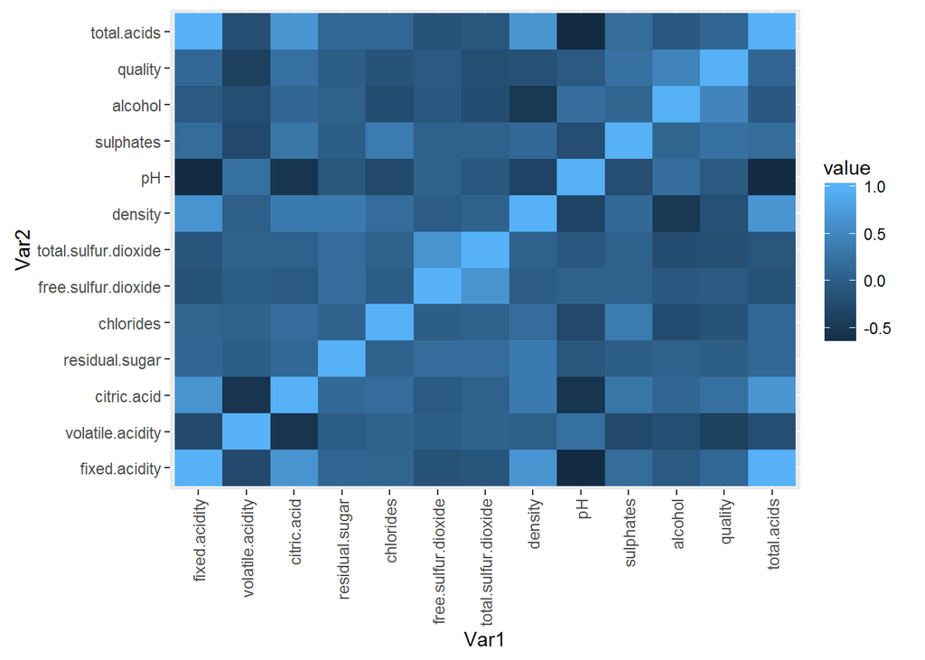

I also printed out the matrix, above, in number form so we can get an exact correlation ,easurement for each interaction.

Next let’s reaxamine the acids and quality as a 2nd variable.

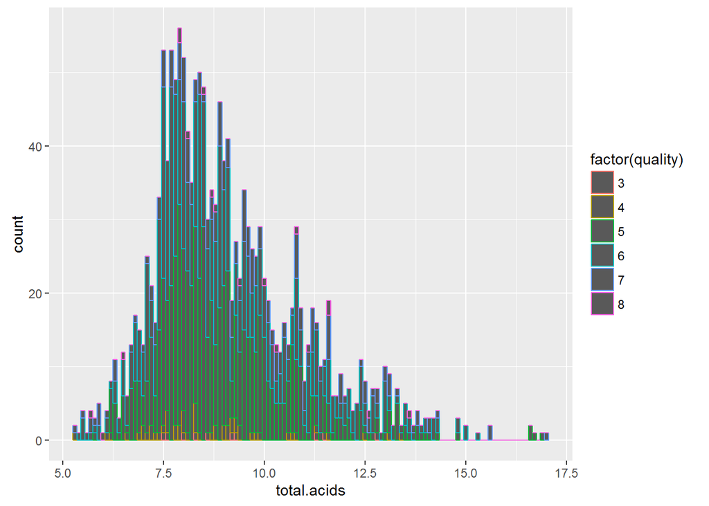

So here we see how quality is distributed across total acidity. It seems that better rated wines are spread out more in the right handed skew. And that wines that are good or bad tend to stay in the lower acid levels. I will not though that great wines can be found at all acid levels. So perhaps bad wines almost always have lower acidity levels, where as good wines tend to have a bit higher acidity levels. Perhaps we can say that acid levels explain a chunk of the variability we see i nred wine quality. Lets look at citri, and volatile acid leveles next!

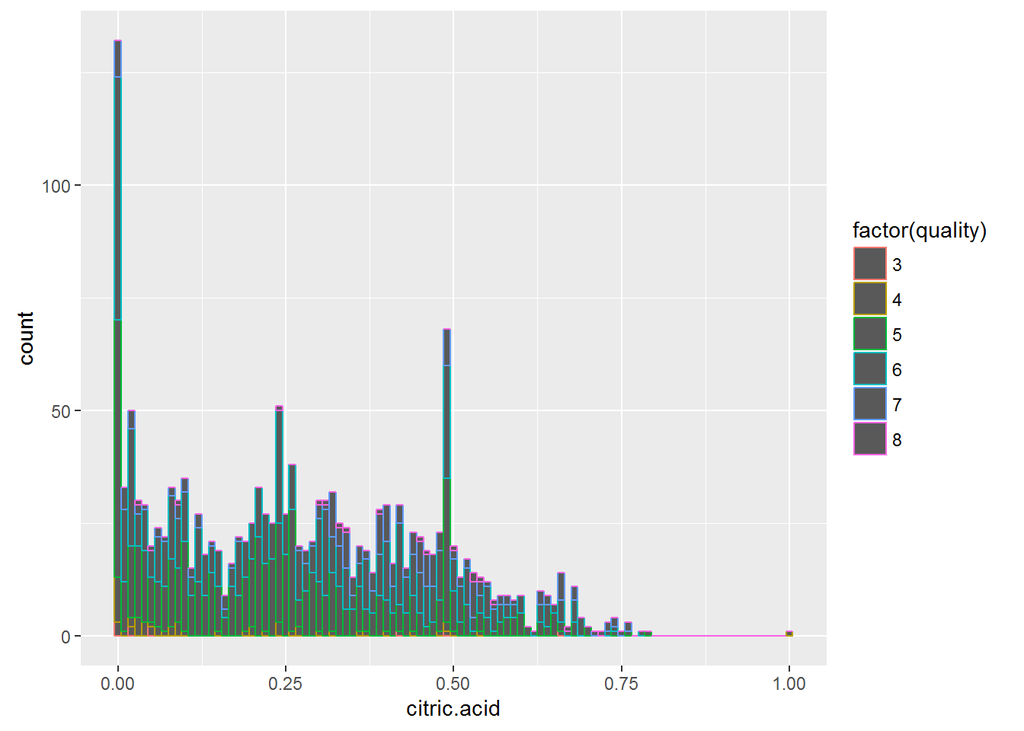

There seems to be a hot spot for poorly rated wines around the 0.00 - 0.10 citric acid range. This in a way supports the prevoious claim about acids and quality. Lets look at volitile acids.

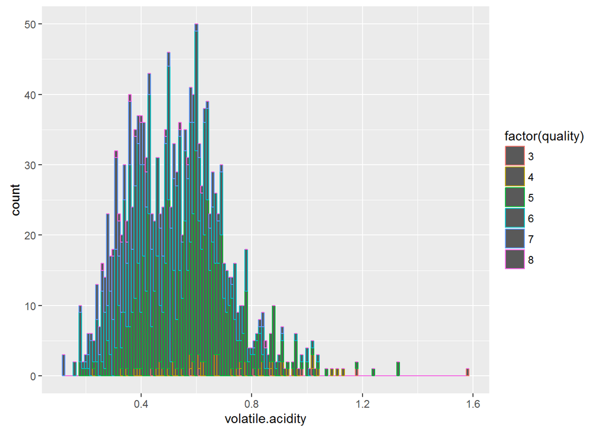

As expected the higher the volaile acids the poorer the wine on average. There seems to be a negative correlation between citric acids and volatile acids.

### Fixed and Total Acids Interaction with pH

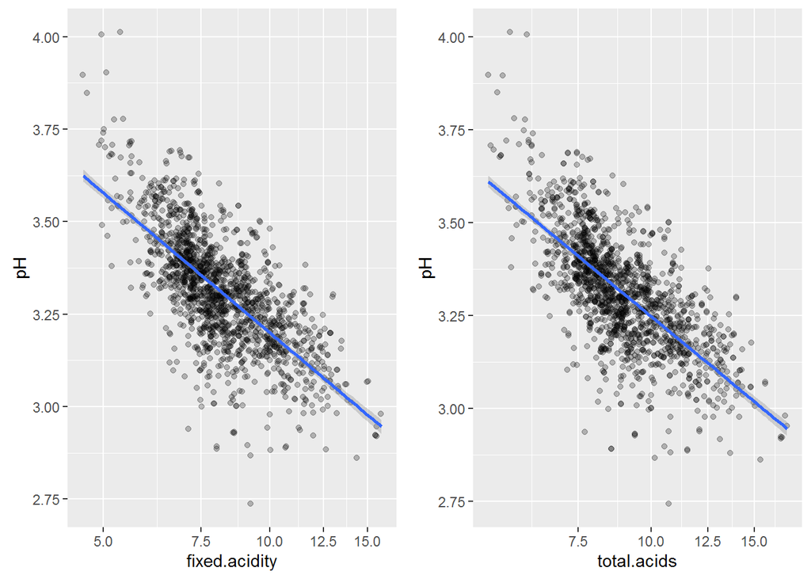

```
##
## Call:
## lm(formula = wine_data$pH ~ log10(wine_data$fixed.acidity))
##
## Residuals:
##      Min       1Q   Median       3Q      Max
## -0.50495 -0.06314  0.00164  0.06477  0.47367
##
## Coefficients:
##                                Estimate Std. Error t value Pr(>|t|)
## (Intercept)                     4.45857    0.02890  154.26   <2e-16 ***
## log10(wine_data$fixed.acidity) -1.25921    0.03158  -39.88   <2e-16 ***
## ---
## Signif. codes:  0 '***' 0.001 '**' 0.01 '*' 0.05 '.' 0.1 ' ' 1
##
## Residual standard error: 0.1093 on 1597 degrees of freedom
## Multiple R-squared:  0.4989, Adjusted R-squared:  0.4986
## F-statistic:  1590 on 1 and 1597 DF,  p-value: < 2.2e-16
```

```
##
## Call:
## lm(formula = wine_data$pH ~ log10(wine_data$total.acids))
##
## Residuals:
##      Min       1Q   Median       3Q      Max
## -0.46869 -0.06359 -0.00024  0.06385  0.48539
##
## Coefficients:
##                              Estimate Std. Error t value Pr(>|t|)
## (Intercept)                   4.55344    0.03144  144.82   <2e-16 ***
## log10(wine_data$total.acids) -1.30534    0.03291  -39.66   <2e-16 ***
## ---
## Signif. codes:  0 '***' 0.001 '**' 0.01 '*' 0.05 '.' 0.1 ' ' 1
##
## Residual standard error: 0.1096 on 1597 degrees of freedom
## Multiple R-squared:  0.4962, Adjusted R-squared:  0.4959
## F-statistic:  1573 on 1 and 1597 DF,  p-value: < 2.2e-16
```

Not suprisingly fixed acidity and total acids had largely the same correlation (each approx -0.68) and spread of data. The main difference between the two are volatile acids.

So far during this analysis I have noticed that alcohol and volatile acids have had interesting interactions with quality. They both seem to have an affect on the quazlity of red wines, so I am going to explore those three variables next.

## Multivariate Plots

### Alcohol and volatile acids affects on Quality

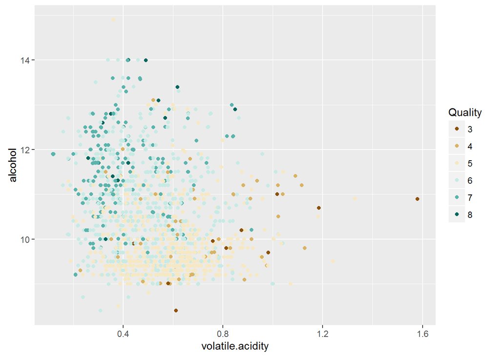

### Alcohol and Total acids affects on Quality

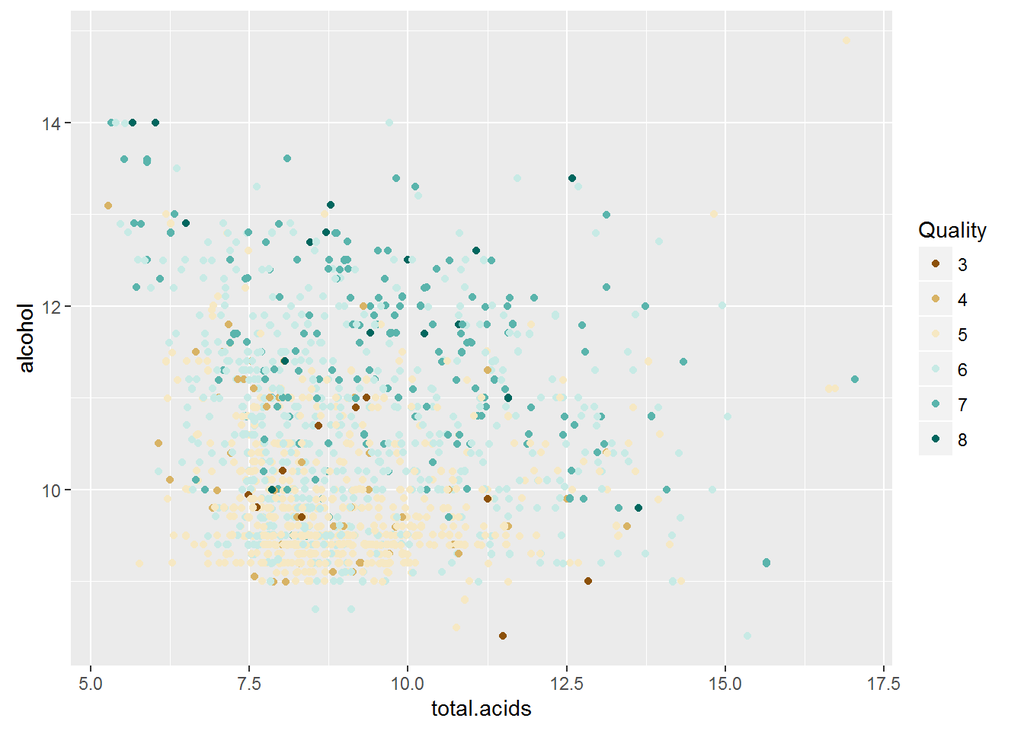

### Alcohol and Citric acids affects on Quality

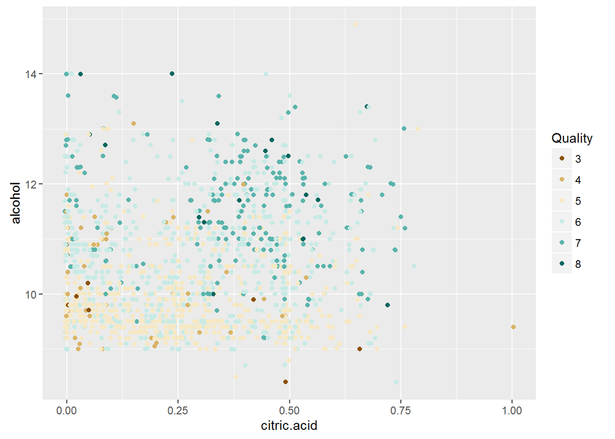

I was expecting to see this more one sided than it was. However there is still a strong connection show. The less citric acid in the red wine the more likely it is to be rated with a lower qulity.

## Final Plots

### Final Plot 1

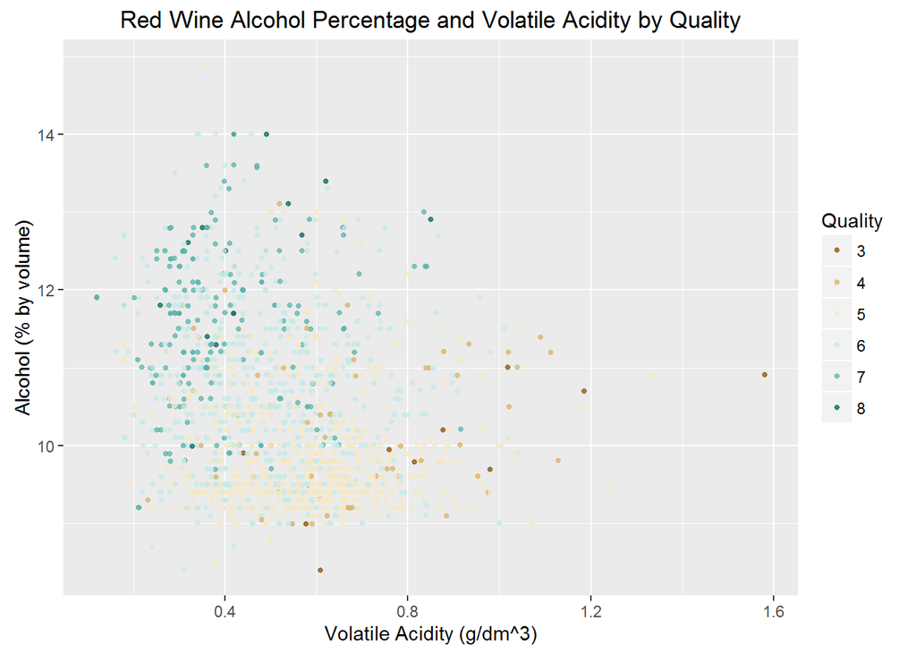

### Final Plot 1 Description

Both Alcohol and Volatile Acidity had seemingly important interactions with a red wine’s quality rating. For example wine with a higher alcohol % tended to taste better, whereas wines with more volatile acidity tasted worse. Suprisingly both alcohol and volatile acidity were not strongly correlated. But together they revealed an important trend. A small amlount of alcohol may be able to overcome acertain amount of volatile acids, but there may be a threshold where alcohol can no longer overcome the acidity of the wine.

### Final Plot 2

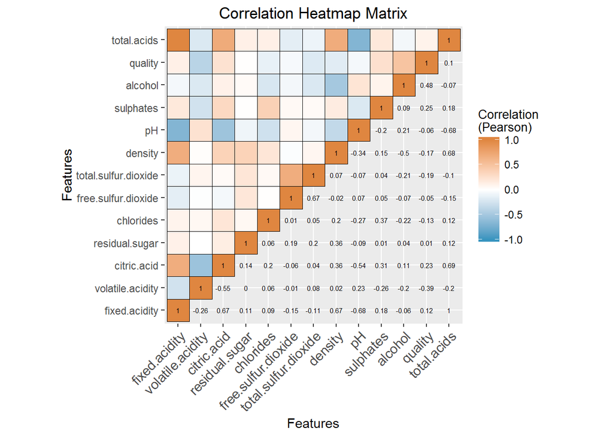

### Final Plot 3

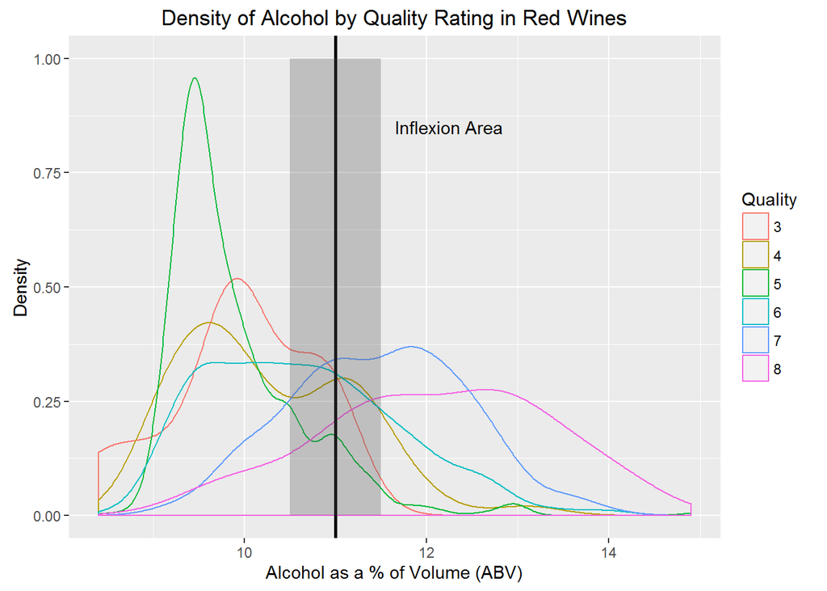

### Final Plot 3 Description

This density plot was interesting because Alcohol had a strong relathionship with quality. I wanted to get an idea for how wines were distributed along an alcohol scale by each level of quality rating. Most wines with the highest and secound highest rating in this data set (8 and 7) had the most amount of alcohol by % in them. All the other mediocre and poor quality wines had a majority of their data set in the lower alcohol range. There was almost sort of an inflexion area around 11% alcohol. I drew a black line at 11% and added a grey rectangle for easy viewing. There you can see the mediocre/poorer quality wines teeter off and the density of the higher quality wines begins to take off.

## Reflection

### Explain any important decisions in the analysis and how those decisions affected the analysis

I choose to add mode/median/mean lines in the univariate graphs a simple way to visually gain more insight from the distributions. Also when dealing with skewed or long tail data, I find having easy to see visual cues helps when analyzing and glossing over all the data. I believe the feature that I engineered did not really add much to the overall analysis. I feel that the analysis perfomed did reveal some of the chemical qualities that have a major impact on quality, those being alcohol and citric/volatile acids.

### Where did I run into difficulties in the analysis?

The univariate plots were all fairly straughtforward. I did run into some issues when trying to build the heatmap correlation matrix and format it correctly as a final graph. A few online resources really helped me to sort through those issues (e.g. removing half of the squares and turning them into NAN data points.Another issue I had was with the quality of data. Not to mean that it was bad data. But perhaps there were only so many avenues to pursue. Alcohol, acids and quality were the real big features that showed good trends. I found the complexity of this data set to offer chalalnges when diciding how much further to explore a relathionship. It was good practice that I am sure will come in handy when working with complex data sets in the future.

### Where did I find successes?

I think the correlaton heatmap matrix really did a great job of laying out all the data and providing some good general overview. I also enjoyed looking at the univariate graphs with mean/median/mode vertical lines. I think it added a good dimmension to the distributions displayed in the graphs.

### How could the analysis be enriched in future work (e.g. additional data and analyses)?

I think combining the features of volatile aciidity and alchool may turn into an interesting feature which could be useful in a ML model. Creating a ML model that could provide a predicition of wine’s quality would be awesome. Especially if you could collect a bunch of data for white wine. Comparing the white wine to red wine data would also yield some great insight. I would guess that white wine would have stronger presences of citric acids. Finally, there could be more analysis preformed on the sulphates and sulfar features.